# Analysis of lentiviral barcoding data - cDC1 versus cDC2 dendritic cells subtypes

### Clone sizes

##### Plot clone-size distributions using a histogram

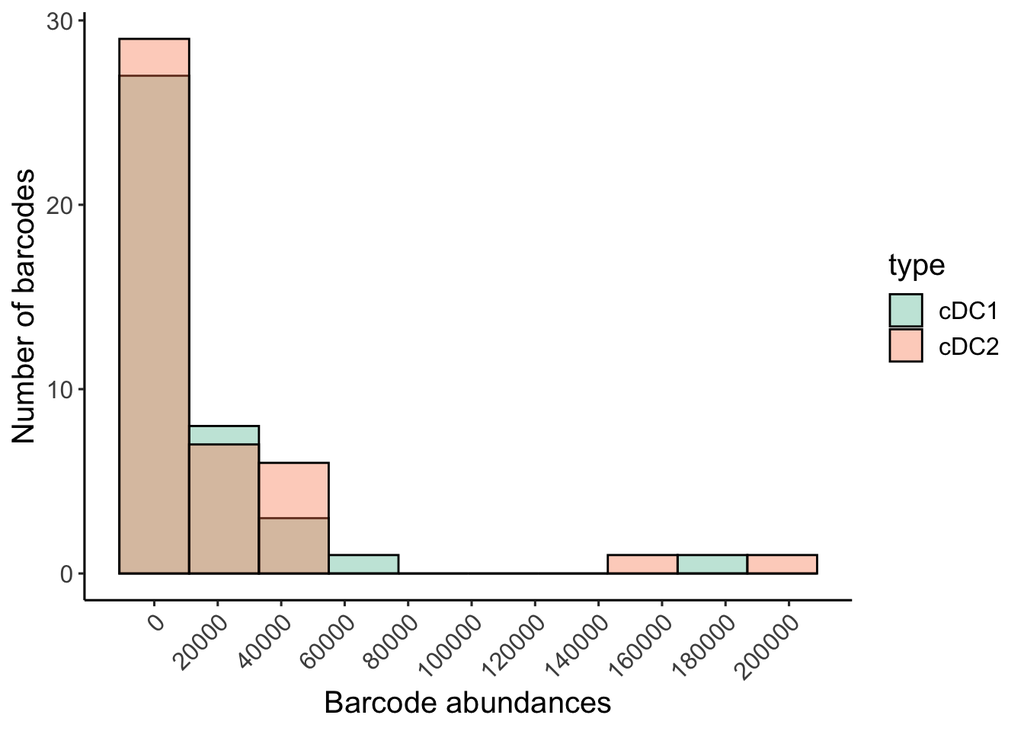

```r
list_var = c("type")
list_val = metadata$type
indiv_val=c("2", "4", "5")
colorFreq="type"

freq_mat<-MakeBarcodeFrequenciesMatrix(count_matrix, metadata, indiv_var, indiv_val, list_var, list_val)
PlotBarcodeFrequencies(freq_mat, colorFreq, y = "histogram", nbins = 10)
```

##### Plot clone-size distributions using a cumulative frequency diagram

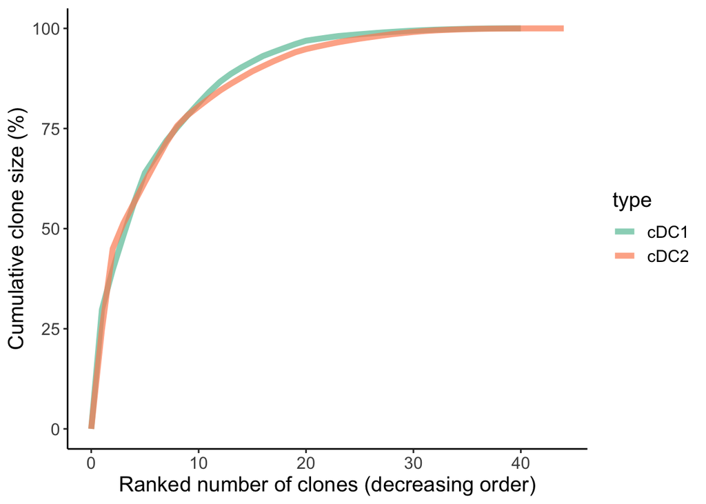

```r
list_var = c("type")
list_val = metadata$type
colorCum="type"

cum_mat<-MakeCumulativeDiagramMatrix(count_matrix, metadata, indiv_var, indiv_val, list_var, list_val, colorCum)
PlotCumulativeDiagram(cum_mat,indiv_var, colorFreq)
```

### Diversity

##### Quantify clonal diversity between cDC1 and cDC2 using the Shannon Index

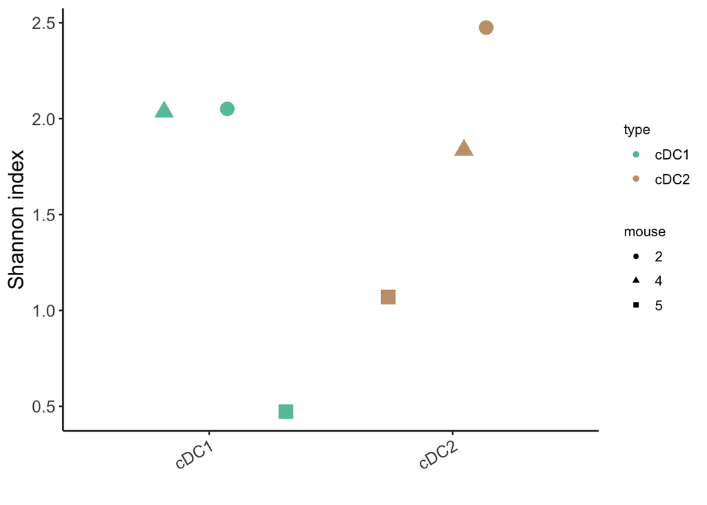

```r
boxplotColor_var=""
diversityVar<-"Shannon index"

div_mat<-CalculDiversity(count_matrix, metadata, indiv_var, indiv_val, list_var, list_val ,colorVar=boxplotColor_var, diversity=diversityVar)
PlotDiversity(div_mat, diversityVar, list_var, indiv_var, colorVar=boxplotColor_var, dots = "no")
```

##### Now lets see if barcode abundances are similar between our cDC1 and cDC2 samples using scatter plot and pie chart visualisations

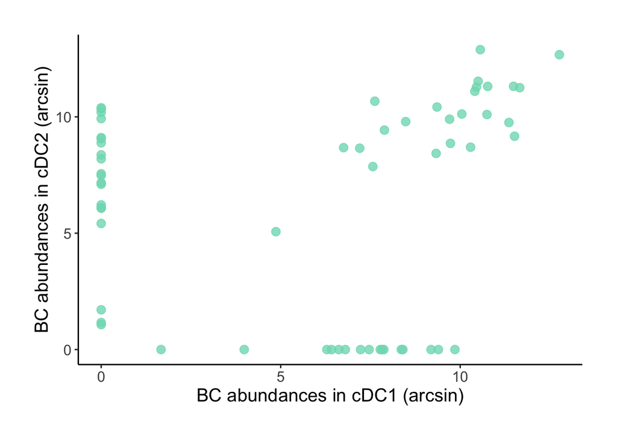

```r
## changing parameters
x_var<-c("type")
x_val<-c("cDC1")
y_var<-c("type")
y_val<-c("cDC2")
color=""

dot_mat<-MakeDotPlotMatrix(count_matrix, metadata, indiv_var, indiv_val,x_var, x_val,y_var, y_val, color)
PlotDotplot(dot_mat, indiv_var, color, textSize = 15)
```

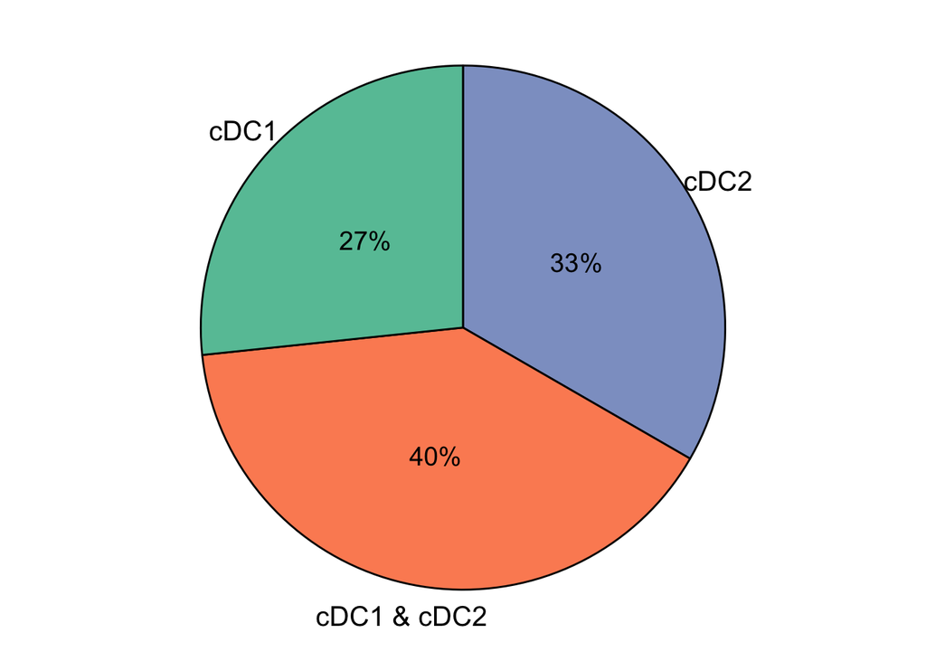

```r
pie_mat<-MakePieChartMatrix(dot_mat, indiv_var, color)
pie<-PlotPieChart(pie_mat, textSize = 5)

# to have legend on piechart (not bellow like done by PlotPieChart function)
pie + guides(fill = guide_legend(title = "Group")) +
    scale_y_continuous(breaks = pie_mat$ypos , labels = pie_mat$Var1)+
    theme(axis.ticks = element_blank(),
          axis.title = element_blank(),
          axis.text = element_text(size = 15),
          legend.position = "none")
```

### Categorisation

In this section we use a threshold-based classifer approach to assign a lineage bias to each barcode. Specifically, we set thresholds of 0,10 and 20% and quantify the number of barcodes that are classified as either cDC1, cDC2 or both.

```r
## common parameters
# Get category variable and values
catVar<-"type"
catVal<-metadata$type
```

##### 0% bias

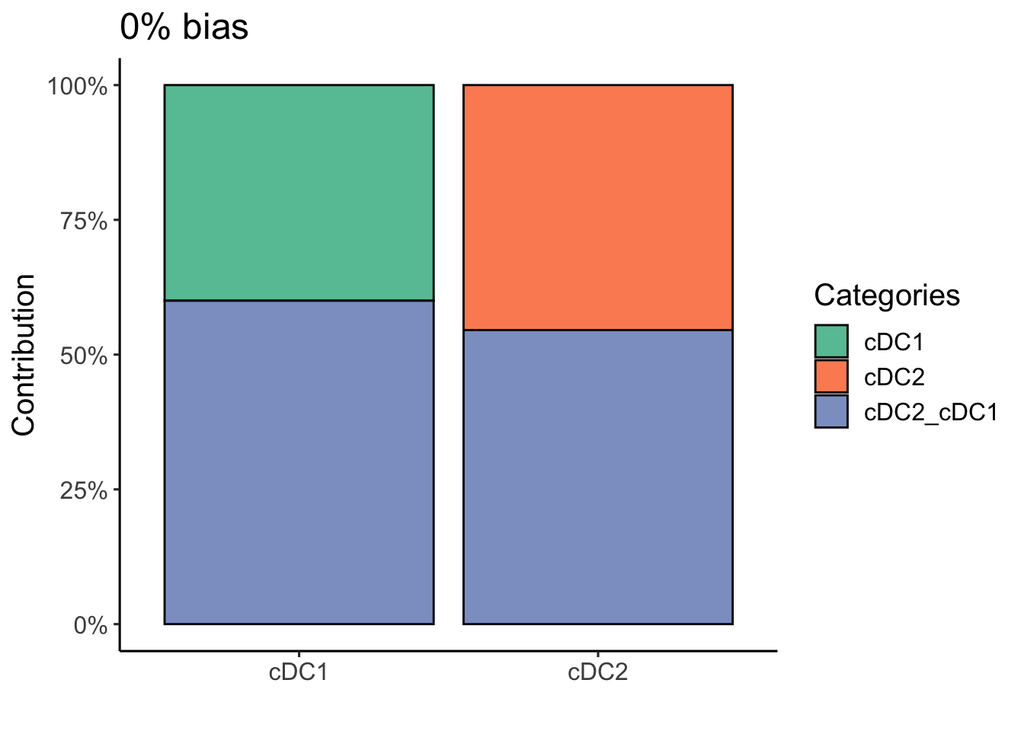

```r
## changing parameters
slider<-0

count_per_type<-MakeCategoryMatrices(count_matrix, metadata, indiv_var, indiv_val, catVar, catVal, slider)[[1]]
PlotCategories(count_per_type, slider)
```

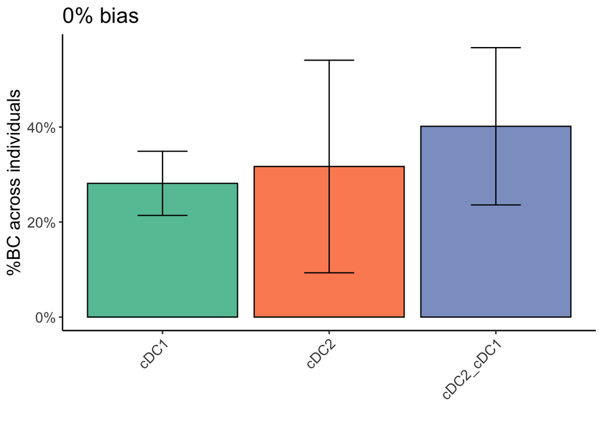

```r
count_per_cat<-MakeCategoryMatrices(count_matrix, metadata, indiv_var, indiv_val, catVar, catVal, slider)[[2]]
PlotCategoryCounts(count_per_cat, slider)
```

##### 10% bias

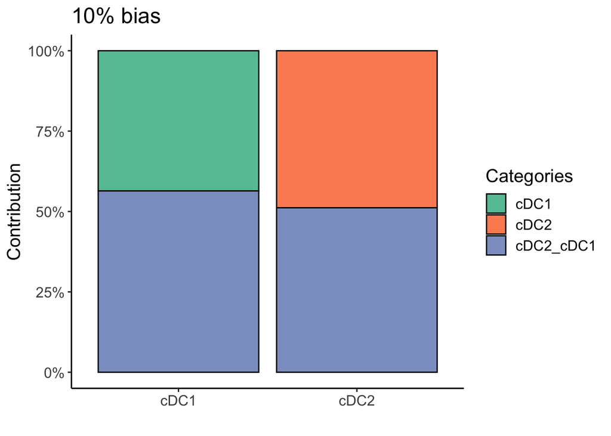

```r
## changing parameters
slider<-10

count_per_type<-MakeCategoryMatrices(count_matrix, metadata, indiv_var, indiv_val, catVar, catVal, slider)[[1]]
PlotCategories(count_per_type, slider)
```

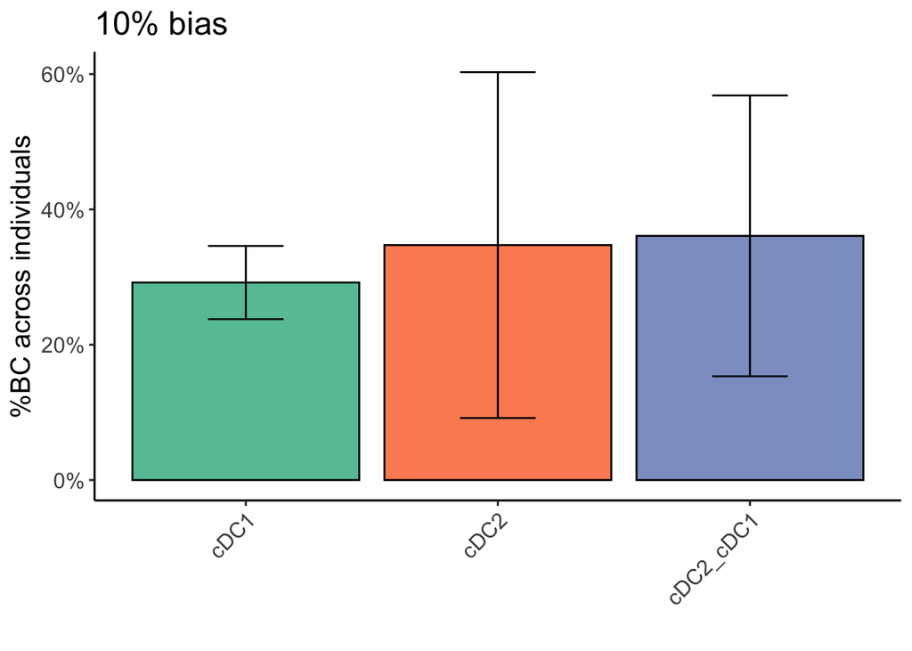

```r
count_per_cat<-MakeCategoryMatrices(count_matrix, metadata, indiv_var, indiv_val, catVar, catVal, slider)[[2]]
PlotCategoryCounts(count_per_cat, slider)
```

##### 20% bias

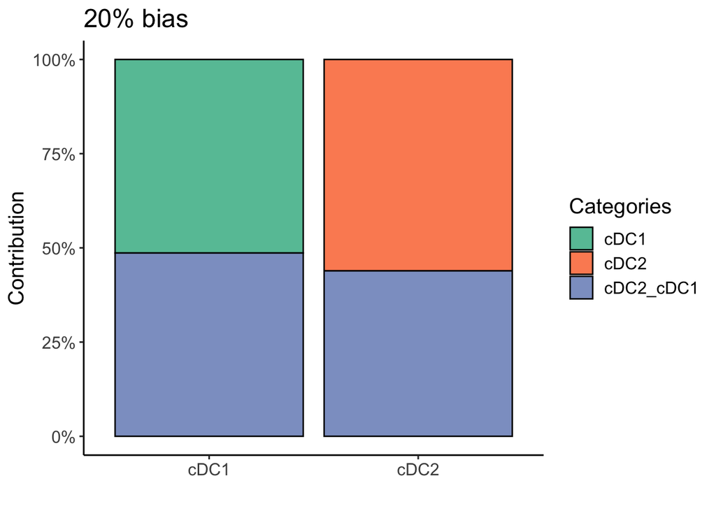

```r
## changing parameters
slider<-20

count_per_type<-MakeCategoryMatrices(count_matrix, metadata, indiv_var, indiv_val, catVar, catVal, slider)[[1]]
PlotCategories(count_per_type, slider)
```

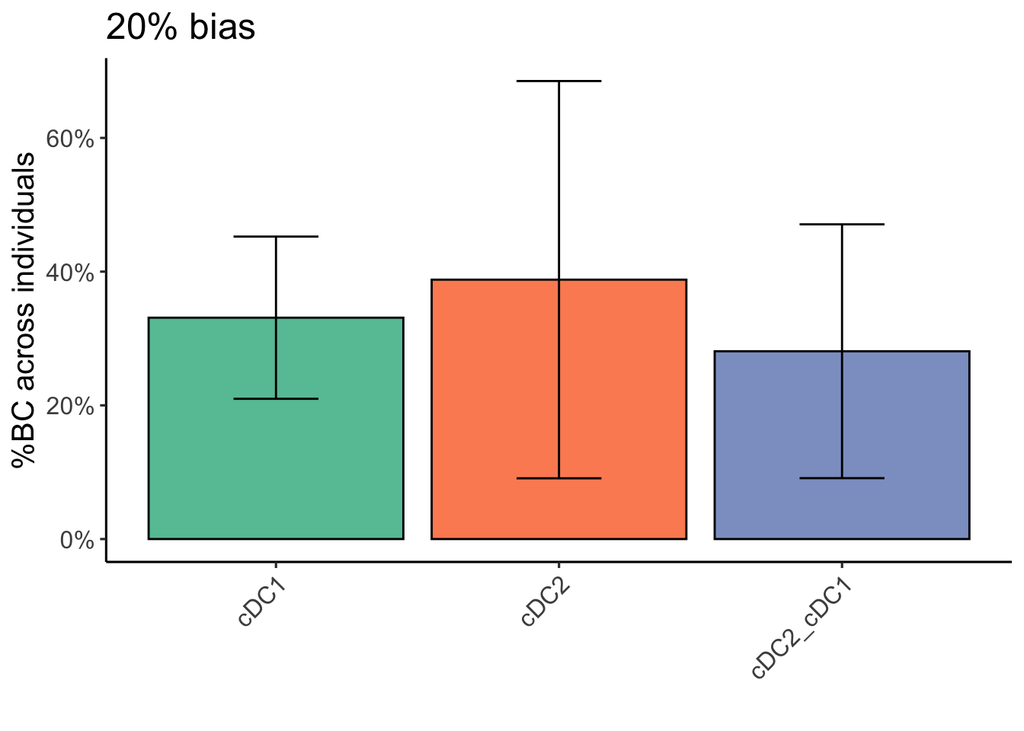

```r
count_per_cat<-MakeCategoryMatrices(count_matrix, metadata, indiv_var, indiv_val, catVar, catVal, slider)[[2]]
PlotCategoryCounts(count_per_cat, slider)
```

# Bias Analysis

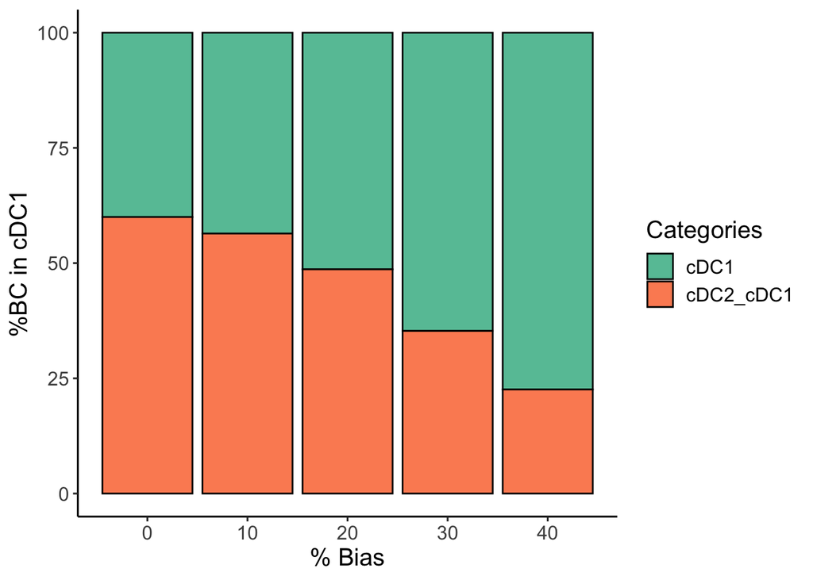

```r
biasType<-MakeBiasPerTypeMatrix(count_matrix, metadata, indiv_var, indiv_val, catVar, catVal)
PlotBiasPerType(biasType, y = "cDC1")
```

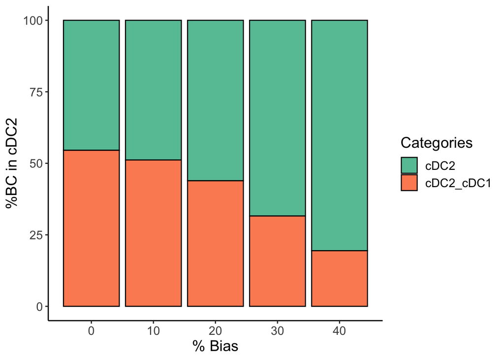

```r
biasType<-MakeBiasPerTypeMatrix(count_matrix, metadata, indiv_var, indiv_val, catVar, catVal)
PlotBiasPerType(biasType, y = "cDC2")
```

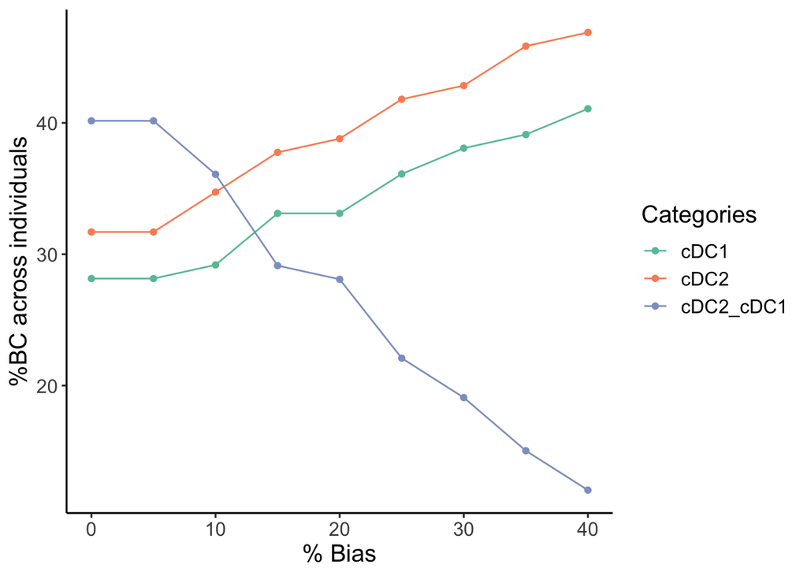

```r
bias<-MakeBiasPerCatMatrix(count_matrix, metadata, indiv_var, indiv_val, catVar, catVal)
PlotBiasPerCat(bias)
```